# Comparar teorías explicativas de la informalidad con SEM

Modelo de medición y modelo de explicación en `lavaan`

12/11/2026

# Presentación

Este ejemplo complementa el manual de validez de constructo. Ahora la informalidad no sólo se **mide**: también se **explica**. Veremos dos cosas:

1. Cómo comparar empíricamente **teorías explicativas rivales** con el ajuste global de modelos SEM.
2. Por qué hay que evaluar **por separado** el modelo de medición (¿medimos bien la informalidad?) y el modelo de explicación (¿qué la causa?).

**Archivos**

- `generar_datos_teorias.R` simula los datos y guarda los parámetros verdaderos. Conviene leerlo **después** de trabajar este manual.
- `manual_teorias_informalidad.Rmd` (este archivo) sólo lee los datos y los analiza.

# 1 El problema

## 1.1 Tres teorías de la informalidad

La literatura ofrece explicaciones rivales de por qué un trabajador es informal (véase Perry et al., 2007):

| Teoría | Mecanismo | Causas en nuestros datos | Signo esperado |
| --- | --- | --- | --- |
| **Dualista** (exclusión) | Sin capital humano suficiente, el trabajador queda fuera del sector formal | `educ` (escolaridad), `edad` | educ (−), edad (+) |
| **Estructuralista** | La estructura productiva genera empleos informales | `micro` (microempresa), `sector` (baja productividad) | (+), (+) |
| **Legalista** (escape) | Los costos de la formalidad empujan a la informalidad | `costo_tramites` (días para abrir un negocio en el municipio) | (+) |

## 1.2 Dos partes de un mismo modelo

Un modelo SEM con una latente explicada tiene dos partes:

- **Modelo de medición.** Cómo los seis indicadores reflejan la informalidad (`INF =~ ...`). Responde: *¿medimos bien el constructo?*
- **Modelo estructural o de explicación.** Qué causas influyen en la informalidad (`INF ~ ...`). Responde: *¿qué teoría explica el constructo?*

Este tipo de modelo, en el que una latente medida con varios indicadores es explicada por variables observadas, se llama **MIMIC** (*multiple indicators, multiple causes*).

## 1.3 Cada teoría es un conjunto de restricciones

La idea clave para comparar teorías: **cada teoría dice qué efectos deben ser cero**.

- La teoría dualista dice: sólo importan `educ` y `edad`; los efectos de `micro`, `sector` y `costo_tramites` son **cero**.
- La estructuralista dice: sólo importan `micro` y `sector`.
- La legalista dice: sólo importa `costo_tramites`.

Un efecto fijado en cero es una **restricción**, y las restricciones se pueden poner a prueba con el ajuste del modelo. Si una teoría fija en cero un efecto que en realidad existe, el modelo ajusta peor.

## 1.4 La estrategia en dos pasos

1. **Primero se evalúa el modelo de medición.** Si los indicadores no miden bien la informalidad, no tiene sentido discutir qué la causa.
2. **Después se comparan las teorías** como restricciones del modelo estructural.

Es la estrategia de Anderson y Gerbing (1988). Veremos que saltársela lleva a conclusiones equivocadas.

# 2 Paquetes y datos

```r
library(lavaan)    # estimación de modelos SEM
library(semPlot)   # diagramas: install.packages("semPlot")
library(ggplot2)   # gráficas
library(knitr)     # kable() para tablas

theme_set(theme_bw(base_size = 12))

if (!file.exists("data/parametros_teorias.rds")) {
  stop("Primero ejecute: source('generar_datos_teorias.R')")
}

# Valores verdaderos de la simulación (sólo para comparar al final)
verdad <- readRDS("data/parametros_teorias.rds")
```

```r
d <- read.csv("data/teorias_informalidad.csv")
head(d)
```

| sin_ss | sin_salud | sin_prest | sin_contrato | pago_efec | sin_registro | educ | edad | micro | sector | costo_tramites |
| --- | --- | --- | --- | --- | --- | --- | --- | --- | --- | --- |
| -0.867 | -1.527 | 0.331 | 0.112 | 0.043 | 0.648 | 5 | 43 | 1 | 0 | 0.812 |
| 0.336 | 0.055 | -0.330 | -1.340 | 0.651 | 1.246 | 13 | 37 | 1 | 0 | 0.338 |
| 0.832 | 0.430 | 0.508 | 1.583 | -1.343 | 1.367 | 3 | 48 | 1 | 1 | 0.607 |
| -0.118 | -0.405 | -1.499 | 0.249 | 1.117 | 0.445 | 13 | 36 | 1 | 0 | 0.519 |
| 1.297 | 0.560 | 1.738 | 0.531 | 0.616 | -0.787 | 11 | 38 | 1 | 0 | 1.873 |
| -1.860 | -1.508 | -0.652 | -3.105 | -1.499 | -1.553 | 14 | 33 | 0 | 0 | -1.122 |

| Variable | Contenido |
| --- | --- |
| `sin_ss`, `sin_salud`, `sin_prest`, `sin_contrato`, `pago_efec`, `sin_registro` | Indicadores de informalidad (respuestas latentes continuas) |
| `educ` | Años de escolaridad |
| `edad` | Edad en años |
| `micro` | 1 si trabaja en una empresa de hasta 5 personas |
| `sector` | 1 si trabaja en un sector de baja productividad |
| `costo_tramites` | Costo de trámites en su municipio (estandarizado) |

¿Cómo se relacionan las posibles causas entre sí? Esto será importante más adelante.

```r
causas <- c("educ", "edad", "micro", "sector", "costo_tramites")
round(cor(d[, causas]), 2)
```

```
                educ  edad micro sector costo_tramites
educ            1.00 -0.04 -0.18  -0.12           0.01
edad           -0.04  1.00 -0.01   0.02          -0.01
micro          -0.18 -0.01  1.00   0.03           0.45
sector         -0.12  0.02  0.03   1.00           0.02
costo_tramites  0.01 -0.01  0.45   0.02           1.00
```

Nótese que `costo_tramites` está correlacionado con `micro`: en los municipios donde abrir un negocio cuesta más hay más microempresas.

Una función auxiliar para reunir índices de ajuste:

```r
ajuste <- function(fit, nombre) {
  indices <- fitMeasures(fit, c("npar", "chisq", "df", "pvalue", "cfi", "tli",
                                "rmsea", "srmr", "aic", "bic"))
  fila <- as.list(round(as.numeric(indices), 3))
  names(fila) <- names(indices)
  data.frame(modelo = nombre, fila, check.names = FALSE)
}
```

# 3 Paso 1: el modelo de medición

Antes de explicar la informalidad, comprobamos que la medimos bien. Estimamos un análisis factorial confirmatorio (CFA) **sólo con los seis indicadores**, sin causas.

```r
modelo_medicion <- '
  # Un factor: la informalidad laboral
  INF =~ sin_ss + sin_salud + sin_prest + sin_contrato + pago_efec + sin_registro
'
fit_medicion <- cfa(modelo_medicion, data = d, std.lv = TRUE)

kable(ajuste(fit_medicion, "Paso 1: modelo de medición (CFA)"))
```

| modelo | npar | chisq | df | pvalue | cfi | tli | rmsea | srmr | aic | bic |
| --- | --- | --- | --- | --- | --- | --- | --- | --- | --- | --- |
| Paso 1: modelo de medición (CFA) | 12 | 13.805 | 9 | 0.129 | 0.999 | 0.998 | 0.016 | 0.009 | 29449.47 | 29516.68 |

Cargas estandarizadas:

```r
cargas <- standardizedSolution(fit_medicion)
cargas[cargas$op == "=~", c("lhs", "op", "rhs", "est.std", "ci.lower", "ci.upper")]
```

| lhs | op | rhs | est.std | ci.lower | ci.upper |
| --- | --- | --- | --- | --- | --- |
| INF | =~ | sin_ss | 0.8023727 | 0.7816658 | 0.8230797 |
| INF | =~ | sin_salud | 0.7697633 | 0.7472502 | 0.7922764 |
| INF | =~ | sin_prest | 0.6911309 | 0.6641928 | 0.7180690 |
| INF | =~ | sin_contrato | 0.7066504 | 0.6805774 | 0.7327234 |
| INF | =~ | pago_efec | 0.6378306 | 0.6080090 | 0.6676522 |
| INF | =~ | sin_registro | 0.6068429 | 0.5754235 | 0.6382624 |

El modelo de medición ajusta bien y todas las cargas son altas. **Ahora sí** podemos pasar a explicar la informalidad.

Si este paso fallara (por ejemplo, por pérdida de independencia local, como en el Caso 1 del manual principal), habría que corregir la medición antes de seguir. Si no, el mal ajuste de la medición se mezclaría con el de las teorías y no sabríamos a cuál culpar.

# 4 Paso 2: el modelo estructural saturado

El **modelo saturado** incluye las cinco causas, todas con efecto libre sobre INF. No impone ninguna teoría: es el modelo más flexible posible para la parte estructural.

```r
modelo_saturado <- '
  # Medición
  INF =~ sin_ss + sin_salud + sin_prest + sin_contrato + pago_efec + sin_registro

  # Explicación: las cinco causas, con efectos libres
  INF ~ educ + edad + micro + sector + costo_tramites
'
fit_saturado <- sem(modelo_saturado, data = d, std.lv = TRUE)

kable(ajuste(fit_saturado, "Paso 2: estructural saturado"))
```

| modelo | npar | chisq | df | pvalue | cfi | tli | rmsea | srmr | aic | bic |
| --- | --- | --- | --- | --- | --- | --- | --- | --- | --- | --- |
| Paso 2: estructural saturado | 17 | 27.692 | 34 | 0.769 | 1 | 1.002 | 0 | 0.009 | 29002.81 | 29098.02 |

Dos observaciones importantes:

- **Ninguna teoría puede ajustar mejor que este modelo.** Todas las teorías son versiones del saturado con algunos efectos fijados en cero. El saturado es el “techo” contra el cual se comparan.
- Su ajuste **no** dice nada sobre las teorías: sólo pone a prueba la medición y un supuesto adicional del MIMIC. Ese supuesto es que **las causas afectan a los indicadores sólo a través de INF** (no hay efectos directos, por ejemplo, de `micro` sobre `sin_registro`).

Podemos revisar ese supuesto con **pruebas de puntaje** (*score tests*). Para cada posible efecto directo de una causa sobre un indicador (6 indicadores × 5 causas = 30 efectos), la prueba indica si agregarlo mejoraría significativamente el ajuste, sin tener que estimar 30 modelos.

```r
indicadores <- c("sin_ss", "sin_salud", "sin_prest", "sin_contrato", "pago_efec", "sin_registro")

# Escribimos los 30 efectos directos posibles: "sin_ss ~ educ", "sin_ss ~ edad", ...
efectos_directos <- c()
for (causa in causas) {
  for (indicador in indicadores) {
    efectos_directos <- c(efectos_directos, paste(indicador, "~", causa))
  }
}
head(efectos_directos)
```

```
[1] "sin_ss ~ educ"       "sin_salud ~ educ"    "sin_prest ~ educ"
[4] "sin_contrato ~ educ" "pago_efec ~ educ"    "sin_registro ~ educ"
```

```r
# Prueba de puntaje para cada efecto (argumento add)
pruebas <- lavTestScore(fit_saturado, add = paste(efectos_directos, collapse = "\n"))$uni
pruebas <- pruebas[order(-pruebas$X2), c("lhs", "X2", "df", "p.value")]
names(pruebas) <- c("efecto_directo", "X2", "gl", "p")
kable(head(pruebas, 5), digits = 3, row.names = FALSE,
      caption = "Los cinco efectos directos con mayor estadístico")
```

Los cinco efectos directos con mayor estadístico

| efecto_directo | X2 | gl | p |
| --- | --- | --- | --- |
| sin_contrato~educ | 3.847 | 1 | 0.050 |
| pago_efec~costo_tramites | 2.021 | 1 | 0.155 |
| sin_salud~costo_tramites | 1.914 | 1 | 0.167 |
| sin_contrato~sector | 1.108 | 1 | 0.293 |
| sin_contrato~edad | 1.053 | 1 | 0.305 |

Con 30 pruebas, esperamos que alrededor de una o dos den p < 0.05 sólo por azar. Una regla prudente es la corrección de Bonferroni: exigir p < 0.05 / 30 ≈ 0.0017. Si ningún efecto la supera, no hay evidencia de efectos directos y el supuesto MIMIC es razonable.

# 5 Paso 3: las teorías como modelos restringidos

Cada teoría se escribe como el modelo saturado con ciertos efectos **fijados en cero** (`0*`). Todos los modelos incluyen las **mismas cinco causas**. Más adelante veremos por qué esto es indispensable.

```r
# Ninguna causa importa: la informalidad no se explica (punto de referencia)
modelo_nulo <- '
  INF =~ sin_ss + sin_salud + sin_prest + sin_contrato + pago_efec + sin_registro
  INF ~ 0*educ + 0*edad + 0*micro + 0*sector + 0*costo_tramites
'

# Teoría dualista: sólo escolaridad y edad
modelo_dualista <- '
  INF =~ sin_ss + sin_salud + sin_prest + sin_contrato + pago_efec + sin_registro
  INF ~ educ + edad + 0*micro + 0*sector + 0*costo_tramites
'

# Teoría estructuralista: sólo microempresa y sector
modelo_estructuralista <- '
  INF =~ sin_ss + sin_salud + sin_prest + sin_contrato + pago_efec + sin_registro
  INF ~ 0*educ + 0*edad + micro + sector + 0*costo_tramites
'

# Teoría legalista: sólo costo de trámites
modelo_legalista <- '
  INF =~ sin_ss + sin_salud + sin_prest + sin_contrato + pago_efec + sin_registro
  INF ~ 0*educ + 0*edad + 0*micro + 0*sector + costo_tramites
'

# Teoría integrada: dualista + estructuralista (sin costo de trámites)
modelo_integrado <- '
  INF =~ sin_ss + sin_salud + sin_prest + sin_contrato + pago_efec + sin_registro
  INF ~ educ + edad + micro + sector + 0*costo_tramites
'

fit_nulo            <- sem(modelo_nulo,            data = d, std.lv = TRUE)
fit_dualista        <- sem(modelo_dualista,        data = d, std.lv = TRUE)
fit_estructuralista <- sem(modelo_estructuralista, data = d, std.lv = TRUE)
fit_legalista       <- sem(modelo_legalista,       data = d, std.lv = TRUE)
fit_integrado       <- sem(modelo_integrado,       data = d, std.lv = TRUE)
```

# 6 Paso 4: comparar las teorías con el ajuste global

## 6.1 Tabla de ajuste

Además de los índices de ajuste, reportamos la $R^2$ de INF: qué proporción de la variación de la informalidad explica cada teoría.

```r
modelos <- list(
  "Nulo"            = fit_nulo,
  "Dualista"        = fit_dualista,
  "Estructuralista" = fit_estructuralista,
  "Legalista"       = fit_legalista,
  "Integrada"       = fit_integrado,
  "Saturado"        = fit_saturado
)

tabla <- do.call(rbind, lapply(names(modelos), function(n) ajuste(modelos[[n]], n)))
tabla$R2_INF <- sapply(modelos, function(f) lavInspect(f, "r2")[["INF"]])
kable(tabla, digits = 3)
```

| modelo | npar | chisq | df | pvalue | cfi | tli | rmsea | srmr | aic | bic | R2_INF |
| --- | --- | --- | --- | --- | --- | --- | --- | --- | --- | --- | --- |
| Nulo | 12 | 484.357 | 39 | 0.000 | 0.910 | 0.896 | 0.076 | 0.116 | 29449.47 | 29516.68 | 0.000 |
| Dualista | 14 | 276.082 | 37 | 0.000 | 0.952 | 0.941 | 0.057 | 0.078 | 29245.19 | 29323.61 | 0.114 |
| Estructuralista | 14 | 180.177 | 37 | 0.000 | 0.971 | 0.965 | 0.044 | 0.058 | 29149.29 | 29227.70 | 0.163 |
| Legalista | 13 | 463.920 | 38 | 0.000 | 0.914 | 0.898 | 0.075 | 0.108 | 29431.03 | 29503.85 | 0.012 |
| Integrada | 16 | 28.570 | 35 | 0.770 | 1.000 | 1.002 | 0.000 | 0.010 | 29001.68 | 29091.30 | 0.235 |
| Saturado | 17 | 27.692 | 34 | 0.769 | 1.000 | 1.002 | 0.000 | 0.009 | 29002.81 | 29098.02 | 0.236 |

## 6.2 El ajuste global puede engañar

Con los criterios habituales (CFI > 0.95, RMSEA < 0.06), la teoría **estructuralista** parece aceptable, y la dualista está en el límite. ¿Significa que esas teorías son correctas?

No necesariamente. El ajuste global mezcla dos cosas:

- el ajuste del modelo de **medición**, que es muy bueno y aporta la mayoría de los grados de libertad;
- el ajuste de la parte de **explicación**, que es lo que distingue a las teorías.

Un modelo de medición excelente puede **esconder** una teoría equivocada. Para evaluar la teoría hay que aislar la parte estructural.

## 6.3 Pruebas de razón de verosimilitud contra el saturado

Cada teoría es un caso particular del modelo saturado. La diferencia de ji cuadrada mide **sólo** el costo de las restricciones de la teoría: cuánto empeora el ajuste por fijar en cero los efectos que la teoría dice que no existen.

```r
lavTestLRT(fit_dualista,        fit_saturado)
```

|  | Df | AIC | BIC | Chisq | Chisq diff | RMSEA | Df diff | Pr(>Chisq) |
| --- | --- | --- | --- | --- | --- | --- | --- | --- |
| fit_saturado | 34 | 29002.81 | 29098.02 | 27.69229 | NA | NA | NA | NA |
| fit_dualista | 37 | 29245.20 | 29323.61 | 276.08218 | 248.3899 | 0.2022333 | 3 | 0 |

```r
lavTestLRT(fit_estructuralista, fit_saturado)
```

|  | Df | AIC | BIC | Chisq | Chisq diff | RMSEA | Df diff | Pr(>Chisq) |
| --- | --- | --- | --- | --- | --- | --- | --- | --- |
| fit_saturado | 34 | 29002.81 | 29098.02 | 27.69229 | NA | NA | NA | NA |
| fit_estructuralista | 37 | 29149.29 | 29227.70 | 180.17726 | 152.485 | 0.1578422 | 3 | 0 |

```r
lavTestLRT(fit_legalista,       fit_saturado)
```

|  | Df | AIC | BIC | Chisq | Chisq diff | RMSEA | Df diff | Pr(>Chisq) |
| --- | --- | --- | --- | --- | --- | --- | --- | --- |
| fit_saturado | 34 | 29002.81 | 29098.02 | 27.69229 | NA | NA | NA | NA |
| fit_legalista | 38 | 29431.03 | 29503.84 | 463.92001 | 436.2277 | 0.2324402 | 4 | 0 |

```r
lavTestLRT(fit_integrado,       fit_saturado)
```

|  | Df | AIC | BIC | Chisq | Chisq diff | RMSEA | Df diff | Pr(>Chisq) |
| --- | --- | --- | --- | --- | --- | --- | --- | --- |
| fit_saturado | 34 | 29002.81 | 29098.02 | 27.69229 | NA | NA | NA | NA |
| fit_integrado | 35 | 29001.68 | 29091.30 | 28.56983 | 0.8775346 | 0 | 1 | 0.3488778 |

Las teorías dualista, estructuralista y legalista se rechazan con claridad: cada una omite efectos que existen. La teoría integrada **no** se rechaza: fijar en cero el efecto del costo de trámites no empeora el ajuste.

## 6.4 Separar medición y explicación

Podemos descomponer la ji cuadrada de cada modelo en dos partes:

$$\chi^2_{\text{total}} =
\underbrace{\chi^2_{\text{saturado}}}_{\text{medición (+ supuesto
MIMIC)}} + \underbrace{\left(\chi^2_{\text{teoría}} -
\chi^2_{\text{saturado}}\right)}_{\text{explicación}} .$$

Para la parte de explicación también calculamos un RMSEA propio, a partir de la diferencia de ji cuadrada y de grados de libertad:

$$\text{RMSEA}_{\Delta} =
\sqrt{\frac{\max(\Delta\chi^2 - \Delta gl,\, 0)}{\Delta gl \cdot (N-1)}}
.$$

A diferencia del RMSEA global, este índice no se “diluye” con los grados de libertad del modelo de medición.

```r
N <- nrow(d)
chi_sat <- fitMeasures(fit_saturado, "chisq")
gl_sat  <- fitMeasures(fit_saturado, "df")

teorias <- c("Nulo", "Dualista", "Estructuralista", "Legalista", "Integrada")

descomp <- do.call(rbind, lapply(teorias, function(n) {
  chi_total <- fitMeasures(modelos[[n]], "chisq")
  gl_total  <- fitMeasures(modelos[[n]], "df")
  dchi <- chi_total - chi_sat
  dgl  <- gl_total - gl_sat
  data.frame(
    teoria          = n,
    chi_total       = chi_total,
    chi_medicion    = chi_sat,
    chi_explicacion = dchi,
    gl_explicacion  = dgl,
    p_explicacion   = pchisq(dchi, dgl, lower.tail = FALSE),
    rmsea_global    = fitMeasures(modelos[[n]], "rmsea"),
    rmsea_explicacion = sqrt(max(dchi - dgl, 0) / (dgl * (N - 1)))
  )
}))
kable(descomp, digits = 3, row.names = FALSE)
```

| teoria | chi_total | chi_medicion | chi_explicacion | gl_explicacion | p_explicacion | rmsea_global | rmsea_explicacion |
| --- | --- | --- | --- | --- | --- | --- | --- |
| Nulo | 484.35737 | 27.69229 | 456.6650758 | 5 | 1.792686e-96 | 0.07556262 | 0.2125773 |
| Dualista | 276.08218 | 27.69229 | 248.3898928 | 3 | 1.459033e-53 | 0.05684048 | 0.2022839 |
| Estructuralista | 180.17726 | 27.69229 | 152.4849697 | 3 | 7.668029e-33 | 0.04398668 | 0.1578817 |
| Legalista | 463.92001 | 27.69229 | 436.2277149 | 4 | 4.121214e-93 | 0.07486128 | 0.2324984 |
| Integrada | 28.56983 | 27.69229 | 0.8775346 | 1 | 3.488778e-01 | 0.00000000 | 0.0000000 |

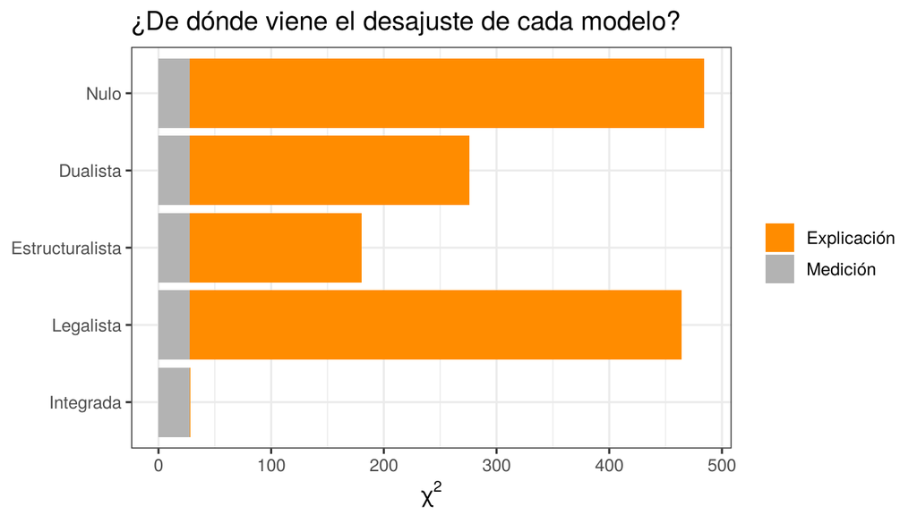

```r
# Formato largo para la gráfica de barras apiladas
barras <- data.frame(
  teoria = factor(rep(descomp$teoria, 2), levels = rev(teorias)),
  parte  = rep(c("Medición", "Explicación"), each = nrow(descomp)),
  chi    = c(descomp$chi_medicion, descomp$chi_explicacion)
)
barras$parte <- factor(barras$parte, levels = c("Explicación", "Medición"))

ggplot(barras, aes(x = chi, y = teoria, fill = parte)) +
  geom_col() +
  scale_fill_manual(values = c("Medición" = "grey70", "Explicación" = "darkorange")) +
  labs(x = expression(chi^2), y = NULL, fill = NULL,
       title = "¿De dónde viene el desajuste de cada modelo?")
```

La parte gris (medición) es la misma en todos los modelos y es pequeña: los indicadores miden bien la informalidad. Lo que distingue a las teorías es la parte naranja.

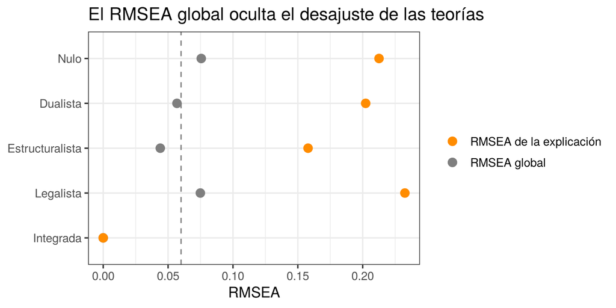

```r
rmsea_largo <- data.frame(
  teoria = factor(rep(descomp$teoria, 2), levels = rev(teorias)),
  tipo   = rep(c("RMSEA global", "RMSEA de la explicación"), each = nrow(descomp)),
  rmsea  = c(descomp$rmsea_global, descomp$rmsea_explicacion)
)

ggplot(rmsea_largo, aes(x = rmsea, y = teoria, colour = tipo)) +
  geom_point(size = 3) +
  geom_vline(xintercept = 0.06, linetype = "dashed", colour = "grey50") +
  scale_colour_manual(values = c("darkorange", "grey50")) +
  labs(x = "RMSEA", y = NULL, colour = NULL,
       title = "El RMSEA global oculta el desajuste de las teorías")
```

## 6.5 Comparar teorías no anidadas: AIC y BIC

Las teorías dualista, estructuralista y legalista **no** son casos particulares unas de otras, así que no se pueden comparar con pruebas de razón de verosimilitud. Para eso se usan los criterios de información: **menor es mejor**. El BIC penaliza más los parámetros y favorece modelos parsimoniosos.

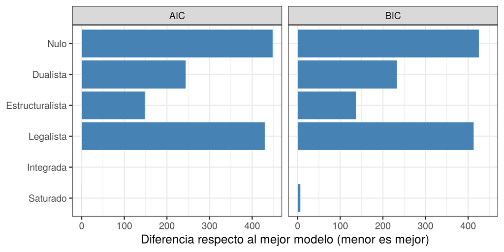

```r
criterios <- data.frame(
  modelo = factor(rep(tabla$modelo, 2), levels = rev(tabla$modelo)),
  criterio = rep(c("AIC", "BIC"), each = nrow(tabla)),
  valor = c(tabla$aic, tabla$bic)
)
# Diferencia respecto al mejor modelo de cada criterio
criterios$delta <- ave(criterios$valor, criterios$criterio, FUN = function(v) v - min(v))

ggplot(criterios, aes(x = delta, y = modelo)) +
  geom_col(fill = "steelblue") +
  facet_wrap(~ criterio) +
  labs(x = "Diferencia respecto al mejor modelo (menor es mejor)", y = NULL)
```

# 7 Paso 5: ¿por qué la teoría legalista parecía importar?

Comparemos el efecto estimado de cada causa en los distintos modelos. Usamos la solución `std.lv`: el efecto de una unidad de la causa sobre INF, medida en desviaciones estándar.

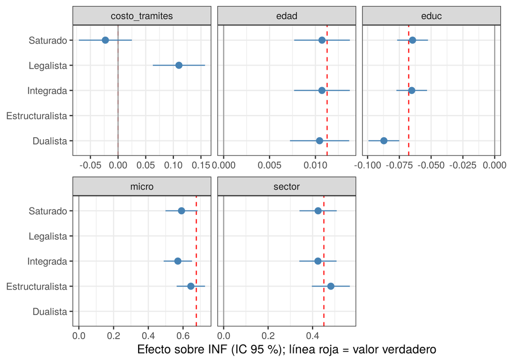

```r
coeficientes <- do.call(rbind, lapply(c("Dualista", "Estructuralista", "Legalista",
                                        "Integrada", "Saturado"), function(n) {
  s <- standardizedSolution(modelos[[n]], type = "std.lv")
  s <- s[s$op == "~" & s$lhs == "INF", c("rhs", "est.std", "ci.lower", "ci.upper")]
  s <- s[s$est.std != 0 | s$ci.lower != s$ci.upper, ]   # quitamos los fijados en 0
  data.frame(modelo = n, s)
}))
names(coeficientes) <- c("modelo", "causa", "est", "inf", "sup")

# Valores verdaderos en la misma escala
valores_verdaderos <- data.frame(
  causa = causas,
  est   = c(verdad$b_educ, verdad$b_edad, verdad$b_micro,
            verdad$b_sector, verdad$b_costo) / verdad$sd_INF
)

ggplot(coeficientes, aes(x = est, y = modelo)) +
  geom_vline(data = valores_verdaderos, aes(xintercept = est),
             colour = "red", linetype = "dashed") +
  geom_vline(xintercept = 0, colour = "grey60") +
  geom_pointrange(aes(xmin = inf, xmax = sup), colour = "steelblue") +
  facet_wrap(~ causa, scales = "free_x") +
  labs(x = "Efecto sobre INF (IC 95 %); línea roja = valor verdadero", y = NULL)
```

En el modelo legalista, el costo de trámites tiene un efecto positivo y significativo. Pero en el modelo saturado el efecto desaparece. ¿Por qué?

- El costo de trámites está correlacionado con la presencia de **microempresas**.
- El modelo legalista fija en cero el efecto de `micro`, así que el costo de trámites “absorbe” parte de ese efecto: es un **sesgo por variable omitida**.
- Cuando las teorías se ponen a competir en el mismo modelo, el efecto aparente desaparece.

La $R^2$ cuenta la misma historia: la teoría legalista explica apenas 1.2 % de la variación de la informalidad.

# 8 Paso 6: ajuste no es explicación

El ajuste y la $R^2$ responden preguntas distintas:

- El **ajuste** evalúa si las **restricciones** de la teoría (los ceros) son compatibles con los datos.
- La $R^2$ evalúa **cuánto** de la informalidad explican las causas incluidas.

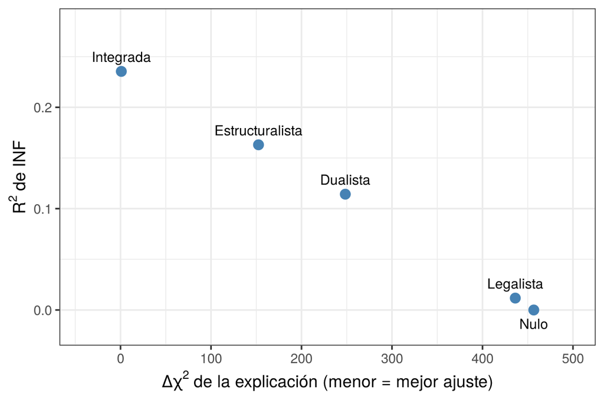

```r
explicacion <- data.frame(
  teoria = descomp$teoria,
  chi_explicacion = descomp$chi_explicacion,
  R2 = tabla$R2_INF[match(descomp$teoria, tabla$modelo)]
)

# Posición de las etiquetas: arriba del punto, salvo "Nulo" (abajo, para no encimarse)
explicacion$ajuste_v <- ifelse(explicacion$teoria == "Nulo", 1.8, -0.9)

ggplot(explicacion, aes(x = chi_explicacion, y = R2, label = teoria)) +
  geom_point(size = 3, colour = "steelblue") +
  geom_text(aes(vjust = ajuste_v), size = 3.5) +
  scale_x_continuous(expand = expansion(mult = 0.15)) +
  scale_y_continuous(limits = c(-0.02, max(explicacion$R2) * 1.2)) +
  labs(x = expression(paste(Delta, chi^2, " de la explicación (menor = mejor ajuste)")),
       y = expression(R^2 ~ "de INF"))
```

La teoría integrada ajusta tan bien como el modelo saturado y explica alrededor de 24 % de la variación de la informalidad. Que no explique más **no** es un problema de ajuste: el modelo puede ser correcto en sus restricciones y aun así dejar mucha variación sin explicar (otras causas no incluidas, factores individuales).

# 9 El error más común: quitar variables en lugar de fijar efectos en cero

Una tentación natural es escribir cada teoría **sólo con sus causas**, por ejemplo `INF ~ educ + edad` para la dualista, sin las demás variables. El problema es que entonces cada modelo describe **datos distintos**: la ji cuadrada se calcula sobre otra matriz de covarianzas, con otros grados de libertad, y las comparaciones dejan de tener sentido.

```r
# Teoría dualista escrita SÓLO con sus causas
modelo_dualista_mal <- '
  INF =~ sin_ss + sin_salud + sin_prest + sin_contrato + pago_efec + sin_registro
  INF ~ educ + edad
'
fit_dualista_mal <- sem(modelo_dualista_mal, data = d, std.lv = TRUE)

# Teoría estructuralista escrita SÓLO con sus causas
modelo_estructuralista_mal <- '
  INF =~ sin_ss + sin_salud + sin_prest + sin_contrato + pago_efec + sin_registro
  INF ~ micro + sector
'
fit_estructuralista_mal <- sem(modelo_estructuralista_mal, data = d, std.lv = TRUE)

kable(rbind(
  ajuste(fit_dualista_mal,        "Dualista, sin las demás causas"),
  ajuste(fit_estructuralista_mal, "Estructuralista, sin las demás causas"),
  ajuste(fit_dualista,            "Dualista, con 0* (correcto)"),
  ajuste(fit_estructuralista,     "Estructuralista, con 0* (correcto)")
))
```

| modelo | npar | chisq | df | pvalue | cfi | tli | rmsea | srmr | aic | bic |
| --- | --- | --- | --- | --- | --- | --- | --- | --- | --- | --- |
| Dualista, sin las demás causas | 14 | 20.231 | 19 | 0.381 | 1.000 | 1.000 | 0.006 | 0.009 | 29245.19 | 29323.61 |
| Estructuralista, sin las demás causas | 14 | 18.543 | 19 | 0.486 | 1.000 | 1.000 | 0.000 | 0.009 | 29149.29 | 29227.70 |
| Dualista, con 0* (correcto) | 14 | 276.082 | 37 | 0.000 | 0.952 | 0.941 | 0.057 | 0.078 | 29245.19 | 29323.61 |
| Estructuralista, con 0* (correcto) | 14 | 180.177 | 37 | 0.000 | 0.971 | 0.965 | 0.044 | 0.058 | 29149.29 | 29227.70 |

Escritas sin las demás causas, ambas teorías ajustan casi perfecto. Cada modelo sólo tiene que reproducir las covarianzas de **sus** variables y nunca se enfrenta a la evidencia de las causas que omite. Con `0*`, todas las teorías se evalúan contra los mismos datos y se ve cuál es compatible con ellos.

Un detalle técnico: el AIC y el BIC **coinciden** en las dos versiones. Con causas exógenas, `lavaan` calcula la verosimilitud de los indicadores *dado* el valor de las causas, y una causa con efecto cero no cambia esa verosimilitud. La que cambia es la ji cuadrada. Ésta compara cada modelo con un modelo saturado, y el saturado de la versión “sin las demás causas” no las incluye: no tiene forma de saber que esas causas influyen en la informalidad.

# 10 El modelo preferido

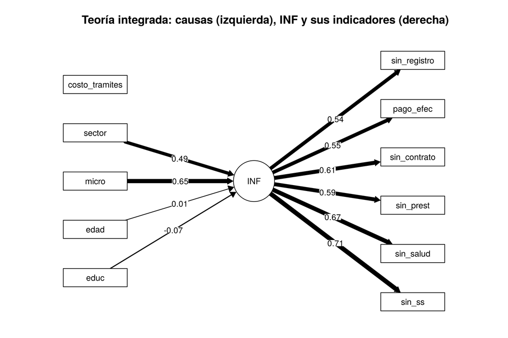

```r
semPaths(fit_integrado, what = "est", whatLabels = "est",
         layout = "tree2", rotation = 2, style = "lisrel",
         intercepts = FALSE, residuals = FALSE, exoCov = FALSE,
         nCharNodes = 0, shapeMan = "rectangle", sizeMan = 14, sizeMan2 = 4,
         sizeLat = 9, label.scale = FALSE, label.cex = 0.9,
         edge.label.cex = 0.8, edge.color = "black", fade = FALSE,
         mar = c(3, 6, 5, 6))
title("Teoría integrada: causas (izquierda), INF y sus indicadores (derecha)", line = 2)
```

Resumen de la evidencia:

| Pregunta | Herramienta | Resultado |
| --- | --- | --- |
| ¿Medimos bien la informalidad? | CFA (paso 1) | Sí: buen ajuste y cargas altas |
| ¿Las causas afectan a los indicadores sólo a través de INF? | Modelo saturado e índices de modificación | Sí: sin efectos directos importantes |
| ¿Qué teorías son compatibles con los datos? | $\Delta\chi^2$ contra el saturado, RMSEA de la explicación | Sólo la integrada |
| ¿Cuál es preferible entre modelos no anidados? | AIC, BIC | La integrada |
| ¿Cuánto explica? | $R^2$ de INF | Una parte moderada |

# 11 Para discutir

1. La teoría estructuralista tiene CFI = 0.971 y RMSEA = 0.044. Con los criterios usuales se “aceptaría”. ¿Qué información adicional cambia esa conclusión?
2. ¿Qué pasaría con la comparación de teorías si el modelo de medición tuviera problemas, por ejemplo, un factor de autoempleo que afecta a tres indicadores?
3. El costo de trámites se mide a nivel municipal y los trabajadores de un mismo municipio comparten su valor. ¿Qué problema genera esto para los errores estándar?
4. Si la relación entre microempresa e informalidad fuera en ambos sentidos (los trabajadores informales crean microempresas), ¿podría este modelo distinguirlo?
5. ¿Por qué una $R^2$ moderada no invalida a la teoría integrada?

# Referencias

- Anderson, J. C. y Gerbing, D. W. (1988). Structural equation modeling in practice: A review and recommended two-step approach. *Psychological Bulletin*, 103, 411–423.
- McDonald, R. P. y Ho, M.-H. R. (2002). Principles and practice in reporting structural equation analyses. *Psychological Methods*, 7, 64–82.
- Perry, G. E., Maloney, W. F., Arias, O. S., Fajnzylber, P., Mason, A. D. y Saavedra-Chanduvi, J. (2007). *Informality: Exit and Exclusion*. Banco Mundial.
- Bollen, K. A. (1989). *Structural Equations with Latent Variables*. Wiley.